# Introduction

Le Printemps arabe, déclenché en décembre 2010 en Tunisie, a marqué un tournant politique majeur dans plusieurs pays du monde arabe. Des soulèvements populaires ont rapidement émergé en Égypte, en Libye, en Syrie, au Yémen et dans d’autres États, chacun avec ses spécificités, mais tous portés par une même aspiration : celle d’une jeunesse en quête de justice sociale, de liberté politique et d’opportunités économiques. Ces mouvements souvent accompagnés de violences significatives ont profondément bouleversé les équilibres sociaux, économiques et institutionnels des pays concernés.

En Égypte, ces dynamiques ont trouvé un écho particulièrement fort. Le pays a été au cœur de l’actualité internationale avec un mouvement révolutionnaire massif qui, en février 2011, a conduit à la chute du président Hosni Moubarak, au pouvoir depuis près de trente ans. Ce soulèvement, largement pacifique au départ, a mobilisé des millions de citoyens de tous horizons sociaux, avec une jeunesse qui s’est imposée comme le principal moteur du changement.

Si ces événements ont été largement analysés sous l’angle politique, leur impact socioéconomique notamment sur le marché du travail, demeure un objet d’étude essentiel, en particulier lorsqu’on s’intéresse à la jeunesse, souvent première victime du chômage structurel.

Ce mémoire s’inscrit dans cette perspective et se donne pour objectif d’évaluer dans quelle mesure le Printemps arabe a influencé la participation des jeunes Égyptiens au marché du travail. Pour ce faire, nous utiliserons deux bases de données clés : une base de données de 2006 permettant d’établir un état initial de l’emploi des jeunes par gouvernorat, et une autre concernant les violences survenues en 2011, durant les manifestations révolutionnaires. L’étude testera l’hypothèse selon laquelle les gouvernorats affichant les taux d’emploi les plus faibles avant les révoltes seront également ceux qui connaîtront les niveaux de violence les plus élevés durant la révolution. Ce lien, s’il est avéré, pourrait illustrer comment les inégalités d’accès à l’emploi, exacerbées par la crise économique et sociale, ont pu alimenter les tensions sociales et déclencher les mouvements de contestation.

L’analyse reposera sur une approche économétrique, à travers la mise en œuvre de régressions linéaires visant à quantifier la relation entre les taux d’emploi des jeunes en 2006 et l’intensité des violences en 2011.

# Présentation des données

Cette étude repose sur la combinaison de deux sources de données complémentaires. La première est issue de l’enquête ELMPS 2006 (Egypt Labor Market Panel Survey), produite par l’Economic Research Forum. Elle fournit des données individuelles détaillées sur la population Égyptienne en 2006, et permet d’analyser leur situation vis-à-vis du marché du travail. Cette base inclut des informations relatives à l’emploi, au chômage, aux niveaux d’éducation, aux caractéristiques démographiques et socio-économiques des individus. L’ensemble des observations hors de la tranche d’âge des 18-29 ans a été exclu, afin de se concentrer exclusivement sur la jeunesse égyptienne, groupe central de cette recherche.

La seconde base de données, quant à elle, contient des informations agrégées au niveau des gouvernorats sur le nombre d’habitants et le nombre de morts enregistrés en 2011, année marquée par les soulèvements du Printemps arabe. À partir de ces variables, une mesure de l’intensité de la violence a été construite (part des morts dans la population de chaque gouvernorat). Cette base a ensuite été fusionnée avec ELMPS 2006 via l’identifiant des gouvernorats, permettant ainsi de croiser les caractéristiques individuelles observées avant la révolution avec le niveau de violence ayant frappé chaque région en 2011.

Bien que les données socio-économiques datent d’avant la révolution, leur utilisation permet d’examiner dans quelle mesure les conditions initiales d’accès au marché du travail peuvent contribuer à comprendre le contexte de frustration ayant précédé le Printemps arabe, et d’explorer un éventuel lien entre le faible taux d’emploi des jeunes en 2006 et l’intensité des violences observées en 2011 selon les gouvernorats.

Les variables retenues pour cette étude sont décrites dans le tableau ci-dessous.

[output not shown]

## Statistiques

| Variable | Valeurs Manquantes | Moyenne | Écart-Type | Minimum | 1er Quartile | Médiane | 3e Quartile | Maximum |
| --- | --- | --- | --- | --- | --- | --- | --- | --- |
| Age | 0 | 23.08 | 3.35 | 18.00 | 20.00 | 23.00 | 26.00 | 29.00 |
| Niveau_éduc_an | 2478 | 10.94 | 4.59 | 0.00 | 9.00 | 12.00 | 14.00 | 18.00 |
| Durée_chômage | 8399 | 35.62 | 30.87 | 1.00 | 12.00 | 24.00 | 48.00 | 228.00 |
| Nbr_h_travail_sem | 5561 | 49.61 | 16.57 | 2.00 | 40.00 | 48.00 | 60.00 | 120.00 |
| Age_1ère_année_travail | 5070 | 17.43 | 4.52 | 6.00 | 14.00 | 18.00 | 21.00 | 29.00 |
| Nbr_morts | 0 | 366.83 | 701.75 | 14.00 | 49.00 | 77.00 | 151.00 | 2314.00 |
| Nbr_hab | 0 | 4116858.00 | 2014780.44 | 512820.00 | 2622220.00 | 4014490.00 | 4991640.00 | 8470510.00 |
| Part_morts_pop | 0 | 0.06 | 0.08 | 0.01 | 0.01 | 0.03 | 0.08 | 0.28 |

Le tableau descriptif des variables quantitatives met en évidence les principales caractéristiques des jeunes âgés de 18 à 29 ans en Égypte en 2006. Leur âge moyen est de 23 ans, ce qui les situe à la jonction entre études et insertion professionnelle. Avec en moyenne 10,9 années d’éducation, la majorité de l’écahntillon n’a pas accédé à l’enseignement supérieur, ce qui peut constituer un frein à l’emploi. Le chômage s’étend sur une durée moyenne de près de trois ans, avec de fortes disparités, révélant une vulnérabilité économique marquée avant la révolution. Parmi ceux qui occupent un emploi, la durée moyenne hebdomadaire de travail est élevée (près de 50 heures), suggérant des conditions de travail intensives, probablement dans le secteur informel. Enfin, les données sur la violence indiquent une forte hétérogénéité entre gouvernorats, avec un nombre moyen de morts relativement faible mais très inégalement réparti.

## Répartition des différentes variables

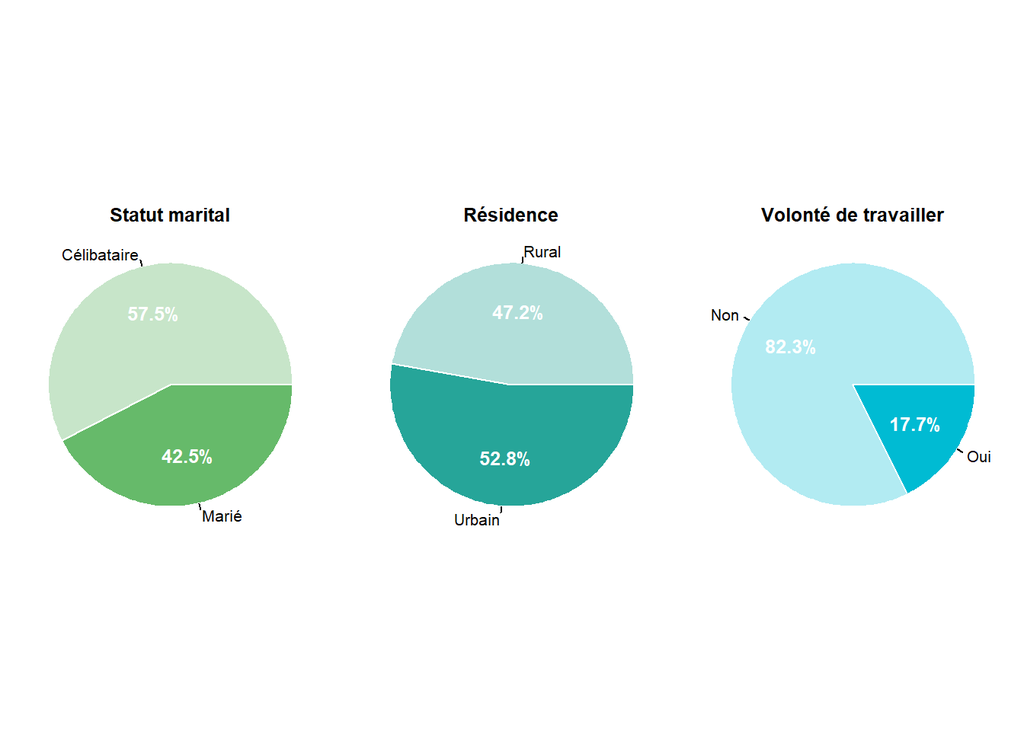

On remarque que près de 60 % des jeunes sont célibataires, tandis qu’environ 40 % sont mariés. Ce résultat est relativement attendu compte tenu de la tranche d’âge considérée, qui inclut à la fois des jeunes adultes au début de leur vie professionnelle et des étudiants. À noter que les jeunes divorcés et veufs, ont été exclus de la base de données en raison de leur faible effectif (moins de 1 % de l’échantillon).

En ce qui concerne le lieu de résidence, les jeunes sont répartis de manière assez équilibrée entre les zones rurales et urbaines, avec une légère majorité en milieu urbain. Cela peut refléter l’urbanisation croissante en Égypte au début des années 2000, où une partie importante de la population jeune migre vers les villes à la recherche de meilleures opportunités d’emploi et d’éducation

Le dernier graphique montre un résultat particulièrement marquant : plus de 80 % des jeunes déclarent ne pas vouloir travailler, contre moins de 20 % qui expriment le souhait d’avoir un emploi. Ce chiffre peut sembler élevé, mais il mérite d’être interprété avec prudence. Il ne signifie pas nécessairement un désintérêt pour le travail en soi, mais peut refléter d’autres réalités : certains jeunes peuvent être encore en études, d’autres peuvent être découragés par le manque d’opportunités, ou encore soumis à des normes sociales (notamment pour les femmes) qui limitent leur participation au marché du travail.

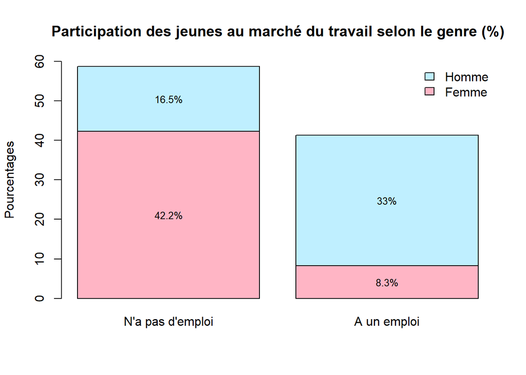

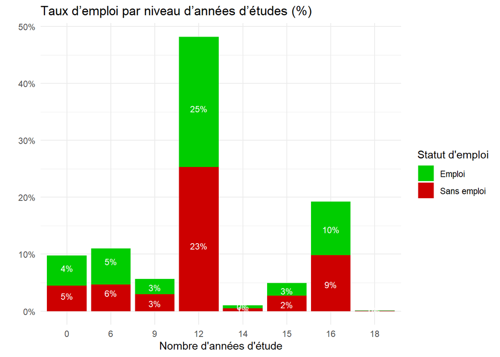

Peu de différence entre les niveaux d’études en termes de statut d’emploi. Cela suggère que le diplôme seul n’explique pas l’accès à l’emploi chez les jeunes.

Le graphique présente le taux d’emploi en fonction du nombre d’années d’études des jeunes adultes en Égypte avant 2011, en lien avec l’impact du Printemps Arabe sur leur participation au marché du travail. Chaque barre est colorée pour indiquer la proportion de jeunes en emploi (vert) par rapport à ceux sans emploi (rouge).

Recommandations pour les politiques publiques :

Ces données pourraient suggérer qu’une réforme du système éducatif, visant à augmenter l’accès à l’éducation de qualité et à améliorer l’employabilité des jeunes, serait bénéfique. En particulier, la transition vers un marché du travail plus inclusif pourrait passer par des investissements dans des formations techniques et professionnelles pour les jeunes ayant un niveau d’étude inférieur à 12 ans.

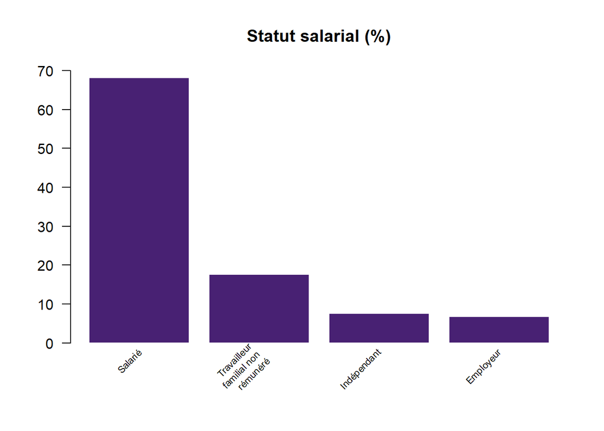

On observe que la grande majorité des jeunes actifs sont salariés, représentant environ 70 %. En parallèle, près de 20 % des jeunes travaillent comme membres non rémunérés au sein de leur famille, reflétant une part importante du travail informel chez les jeunes en Égypte. Enfin, les jeunes indépendants et les jeunes employeurs restent très peu nombreux, un phénomène fréquent chez cette tranche d’âge dans de nombreux pays.

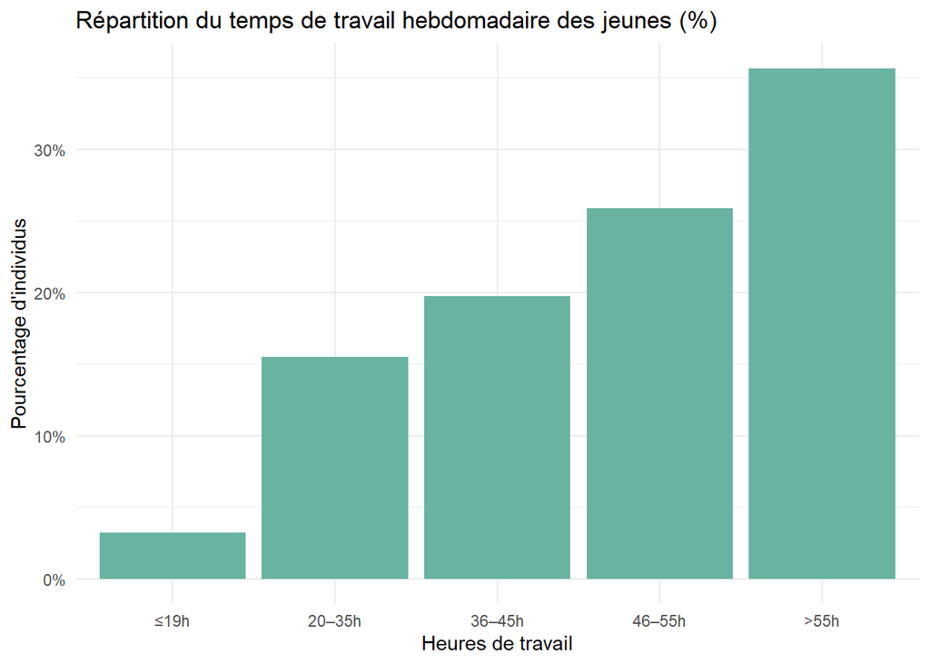

Le graphique révèle que la majorité des jeunes en emploi consacrent un nombre d’heures de travail très élevé chaque semaine : plus de 30 % dépassent les 55 heures, et près de 60 % travaillent au-delà de 45 heures hebdomadaires. À l’inverse, seuls moins de 5 % effectuent moins de 20 heures. Ces chiffres illustrent une forte intensité du travail chez les jeunes actifs, bien au-delà de la durée légale hebdomadaire souvent reconnue dans de nombreux pays, notamment les 35 heures. Cela traduit des conditions de travail particulièrement exigeantes, avec peu de place pour des formes de travail à temps partiel ou flexible.

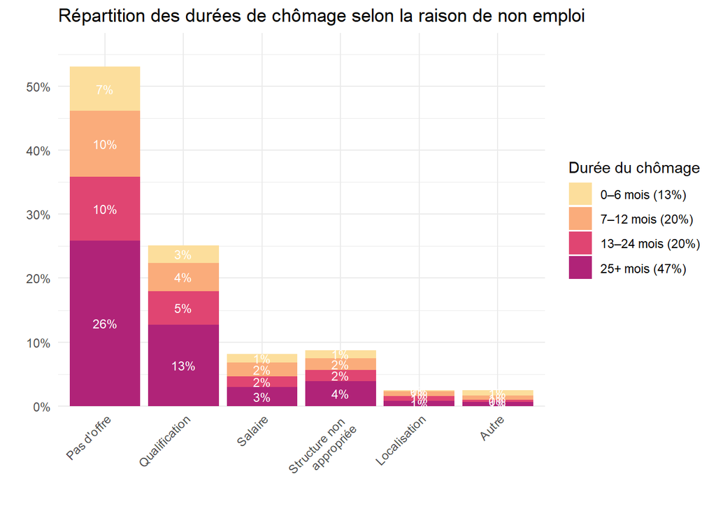

Le graphique ci-dessus présente la répartition des durées de chômage chez les jeunes Égyptiens âgés de 18 à 29 ans en 2006, en fonction de la raison déclarée de non-emploi.

On constate que 47 % des jeunes chômeurs sont sans emploi depuis plus de 25 mois, ce qui témoigne de l’importance du chômage de très longue durée bien avant les événements du Printemps arabe. Cette situation est particulièrement marquée chez ceux qui déclarent ne pas trouver d’offres d’emploi : à elle seule, cette catégorie regroupe plus de 50 % des jeunes chômeurs, dont 26 % en chômage de très longue durée.

La seconde raison la plus fréquente, évoquée par environ 25 % des jeunes chômeurs, est liée à un manque de qualifications, indiquant que de nombreux jeunes ne possèdent pas les compétences requises pour les postes disponibles.

À l’inverse, les motifs liés au salaire, à la localisation ou à une structure non appropriée apparaissent marginaux. Par ailleurs, peu de jeunes trouvent un emploi rapidement, puisque la majorité reste au chômage pendant de longues périodes, ce qui souligne la difficulté d’insertion sur le marché du travail.

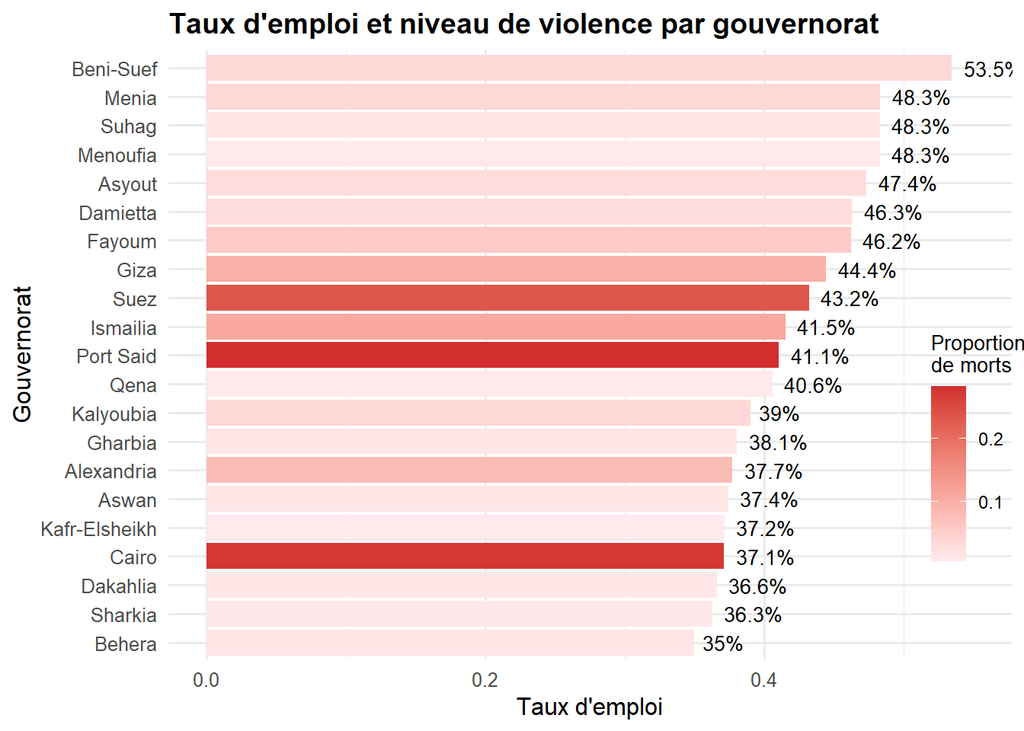

Le graphique ci-dessus présente une visualisation croisée du taux d’emploi des jeunes en 2006 et du niveau de violence lors du Printemps arabe en 2011, mesuré ici par la proportion de morts par gouvernorat, dans le but d’examiner si les régions les plus touchées par le chômage avant les révoltes ont également connu les niveaux de violence les plus élevés.

On constate une variation significative du taux d’emploi des jeunes selon les gouvernorats. Par exemple, Beni-Suef affiche le taux d’emploi le plus élevé (53,5 %), tandis que Behera a le plus faible (35 %). Les gouvernorats où le taux d’emploi était relativement élevé en 2006, comme Beni-Suef, Menia et Suhag, ont aussi connu un faible niveau de violence pendant le Printemps arabe (indiqué par des couleurs plus claires sur le graphique).

Cela montre qu’il n’y a pas de lien évident ou systématique entre un fort taux de chômage des jeunes en 2006 et l’intensité des violences en 2011. D’autres facteurs semblent intervenir, comme la dynamique politique locale, les inégualités sociales ou encore la concentration urbaine. Cette exploration justifie la suite du travail empirique, qui cherchera à tester plus rigoureusement cette relation à travers des régressions économétriques.

# Méthode MCO

Étant donné que la variable mesurant l’intensité de la violence (part des morts dans la population) n’est disponible qu’au niveau agrégé des gouvernorats, l’ensemble des variables individuelles issues de l’ELMPS ont été agrégées sous forme de moyennes par gouvernorat, de manière à garantir la cohérence des niveaux d’analyse dans les régressions.

# Régressions

La variable Résidence_moy correspond à la proportion de la population vivant en zone urbaine dans chaque gouvernorat, calculée à partir d’une variable binaire (1 = urbain, 0 = rural).

## Régression 1

```
Call:
lm(formula = Part_morts_pop ~ Statut_marital_moy + Niveau_éduc_moy +
    Résidence_moy, data = df_mean_gouv)

Residuals:
      Min        1Q    Median        3Q       Max
-0.063507 -0.022383 -0.008077  0.021101  0.087732

Coefficients:
                   Estimate Std. Error t value Pr(>|t|)
(Intercept)        -0.82058    0.32223  -2.547  0.02086 *
Statut_marital_moy  0.29931    0.22594   1.325  0.20279
Niveau_éduc_moy     0.05920    0.02457   2.410  0.02756 *
Résidence_moy       0.21172    0.06359   3.329  0.00397 **
---
Signif. codes:  0 '***' 0.001 '**' 0.01 '*' 0.05 '.' 0.1 ' ' 1

Residual standard error: 0.045 on 17 degrees of freedom
Multiple R-squared:  0.7783,    Adjusted R-squared:  0.7391
F-statistic: 19.89 on 3 and 17 DF,  p-value: 8.452e-06
```

Dans ce premier modèle, deux variables apparaissent comme significatives : le niveau moyen d’éducation des jeunes au sein du gouvernorat (au seuil de 5 %) et la proportion de résidents en milieu urbain (au seuil de 1 %). En revanche, le statut marital des jeunes ne semble pas avoir de lien statistiquement significatif avec la part des morts liées aux violences.

On peut donc en déduire que le nombre d’année d’étude et le degré d’urbanisation jouent un rôle important dans l’intensité des violences observées dans les gouvernorats, ce qui invite à approfondir l’analyse en intégrant d’autres dimensions socio-économiques dans le modèle suivant.

## Régression 2

```
Call:
lm(formula = Part_morts_pop ~ Niveau_éduc_moy + Résidence_moy +
    Age_1ère_année_travail_moy, data = df_mean_gouv)

Residuals:
     Min       1Q   Median       3Q      Max
-0.08071 -0.02020 -0.00747  0.02903  0.09751

Coefficients:
                             Estimate Std. Error t value Pr(>|t|)
(Intercept)                -0.4867177  0.2540125  -1.916   0.0723 .
Niveau_éduc_moy             0.0401094  0.0225528   1.778   0.0932 .
Résidence_moy               0.2005164  0.0774406   2.589   0.0191 *
Age_1ère_année_travail_moy  0.0004456  0.0147755   0.030   0.9763
---
Signif. codes:  0 '***' 0.001 '**' 0.01 '*' 0.05 '.' 0.1 ' ' 1

Residual standard error: 0.04726 on 17 degrees of freedom
Multiple R-squared:  0.7554,    Adjusted R-squared:  0.7122
F-statistic:  17.5 on 3 and 17 DF,  p-value: 1.922e-05
```

Dans ce second modèle, seule la proportion de jeunes vivant en zone urbaine apparaît comme significativement liée à la part des morts liées aux violences, au seuil de 5 %. Le niveau moyen d’éducation est marginalement significatif (au seuil de 10 %), tandis que l’âge moyen à la première année de travail ne présente aucun lien statistiquement significatif avec la violence.

L’augmentation d’une unité de la proportion de jeunes en zone urbaine se traduit en moyenne par une hausse de 0,201 du taux de mortalité lié à la violence.En revanche, le lien avec le niveau d’éducation, plus net dans le modèle précédent, s’atténue ici en présence de nouvelles variables.

Ces observations soulignent l’importance du contexte urbain dans la survenue des violences et suggèrent que d’autres facteurs socio-économiques liés à l’emploi pourraient éclairer davantage ces dynamiques dans le modèle suivant.

## Régression 3

```
Call:
lm(formula = Part_morts_pop ~ Emploi_3mois_H + Emploi_3mois_F,
    data = df_mean_gouv)

Residuals:
     Min       1Q   Median       3Q      Max
-0.08303 -0.07017 -0.01990  0.03304  0.16184

Coefficients:
               Estimate Std. Error t value Pr(>|t|)
(Intercept)      0.4775     0.2159   2.212   0.0401 *
Emploi_3mois_H  -0.6724     0.3152  -2.133   0.0469 *
Emploi_3mois_F   0.2365     0.2324   1.018   0.3223
---
Signif. codes:  0 '***' 0.001 '**' 0.01 '*' 0.05 '.' 0.1 ' ' 1

Residual standard error: 0.08126 on 18 degrees of freedom
Multiple R-squared:  0.2344,    Adjusted R-squared:  0.1493
F-statistic: 2.755 on 2 and 18 DF,  p-value: 0.09037
```

On remarque dans ce troisième modèle que seule la variable représentant l’emploi des hommes sur les trois derniers mois se révèle significative, avec un niveau de confiance de 5 %.

En effet, chaque augmentation d’une unité du taux d’emploi masculin, correspond à une baisse moyenne de 0,672 du taux de mortalité liée à la violence. Ce résultat suggère que l’amélioration de l’emploi chez les hommes pourrait jouer un rôle dans la réduction des violences observées.

Le taux d’emploi féminin, quant à lui, n’apporte pas de lien statistique pertinent. Cette absence de lien peut s’expliquer par le fait que, dans le contexte étudié, la participation des femmes au marché du travail est relativement faible, ce qui limite l’impact de cette variable dans les analyses. Pour cette raison, les régressions suivantes se concentreront principalement sur l’emploi masculin, afin de mieux saisir son influence sur la dynamique des violences.

```
Call:
lm(formula = Part_morts_pop ~ Age_moy + Niveau_éduc_moy + Volonté_travailler_moy +
    Emploi_3mois_H + Statut_marital_moy + Résidence_moy, data = df_mean_gouv)

Residuals:
     Min       1Q   Median       3Q      Max
-0.06245 -0.01818 -0.00467  0.01159  0.08073

Coefficients:
                        Estimate Std. Error t value Pr(>|t|)
(Intercept)            -3.009286   1.048956  -2.869   0.0124 *
Age_moy                 0.089236   0.044993   1.983   0.0673 .
Niveau_éduc_moy         0.057753   0.022651   2.550   0.0231 *
Volonté_travailler_moy -0.005777   0.182136  -0.032   0.9751
Emploi_3mois_H          0.252734   0.264252   0.956   0.3551
Statut_marital_moy      0.277000   0.271172   1.021   0.3244
Résidence_moy           0.179130   0.064464   2.779   0.0148 *
---
Signif. codes:  0 '***' 0.001 '**' 0.01 '*' 0.05 '.' 0.1 ' ' 1

Residual standard error: 0.04146 on 14 degrees of freedom
Multiple R-squared:  0.845, Adjusted R-squared:  0.7786
F-statistic: 12.72 on 6 and 14 DF,  p-value: 5.785e-05
```

Dans ce quatrième modèle, les résultats confirment ce qui avait déjà été observé précédemment : le niveau moyen d’éducation et la proportion de jeunes en zone urbaine restent les deux variables les plus solidement associées au taux de mortalité liée à la violence, avec un seuil de significativité de 5 %. Leur influence se confirme, malgré l’ajout de nouvelles variables comme l’âge moyen (dont l’effet pourrait être plus indirect ou nuancé), l’emploi masculin, le statut marital ou encore la volonté de travailler, qui ne montrent, quant à elles, aucun lien significatif avec le niveau de violence.

Le fait que l’emploi masculin ne soit plus significatif une fois les autres facteurs intégrés indique que le faible taux d’emploi des hommes en 2006 n’explique pas à lui seul la hausse des violences dans les gouvernorats, ce lien étant probablement influencé par d’autres variables socio-économiques.

Ainsi, malgré l’introduction de nouvelles variables, ce modèle renforce l’idée que le niveau d’éducation et l’environnement urbain pèsent de manière constante sur l’intensité des violences. Cela suggère une certaine robustesse de ces deux dimensions explicatives à travers les différentes spécifications testées.

```
Call:
lm(formula = Part_morts_pop ~ Pas_d_offre + Niveau_éduc_moy +
    Résidence_moy + Statut_marital_moy, data = df_mean_gouv)

Residuals:
      Min        1Q    Median        3Q       Max
-0.062907 -0.021878 -0.007386  0.019635  0.088453

Coefficients:
                    Estimate Std. Error t value Pr(>|t|)
(Intercept)        -0.815297   0.333617  -2.444  0.02650 *
Pas_d_offre         0.008852   0.056769   0.156  0.87804
Niveau_éduc_moy     0.058699   0.025510   2.301  0.03517 *
Résidence_moy       0.213173   0.066156   3.222  0.00532 **
Statut_marital_moy  0.287529   0.244681   1.175  0.25714
---
Signif. codes:  0 '***' 0.001 '**' 0.01 '*' 0.05 '.' 0.1 ' ' 1

Residual standard error: 0.04635 on 16 degrees of freedom
Multiple R-squared:  0.7786,    Adjusted R-squared:  0.7233
F-statistic: 14.07 on 4 and 16 DF,  p-value: 4.172e-05
```

Cette ultime régression examine l’effet de la proportion de chômeurs déclarant, parmi les différentes raisons du non-emploi, l’absence d’offre d’emploi en 2006. Les résultats montrent que cette situation spécifique de non-emploi n’est pas significativement liée à la violence observée en 2011 comme en témoigne sa pvalue > 0.1. Cela suggère que cette forme de frustration économique déclarée ne différencie pas statistiquement les gouvernorats plus ou moins touchés par les violences.

Par conséquent, les conclusions précédentes restent inchangées : le niveau moyen d’éducation et la proportion de jeunes en zone urbaine continuent d’être les facteurs socio-économiques les plus fortement associés à la violence.

# Discussion

Cette étude a cherché à évaluer l’impact du Printemps arabe sur la participation des jeunes Égyptiens au marché du travail à partir des données disponibles en 2006, couplées à des données sur la violence en 2011. Si cette approche apporte un premier éclairage sur les liens entre conditions socio-économiques antérieures et intensité des violences, plusieurs limites méthodologiques, notamment d’ordre économétrique, doivent être soulignées.

*1. Limites des données disponibles*

La principale contrainte de cette étude est l’absence de données sur le marché du travail post-révolutionnaire. En effet, disposer uniquement d’une base de données de 2006, antérieure aux événements, et des données sur les violences en 2011, limite fortement la possibilité d’évaluer directement l’évolution de la participation des jeunes au marché du travail suite au Printemps arabe. Cette approche impose de raisonner sur des corrélations indirectes, en faisant l’hypothèse que le niveau d’emploi antérieur et les caractéristiques socio-économiques expliquent en partie l’intensité des violences.

Or, cette hypothèse ne permet pas de saisir les dynamiques réelles du marché du travail dans la période post-2011, ni l’impact direct des réformes ou des politiques mises en œuvre après la révolution. Une analyse en série temporelle, reposant sur des données longitudinales couvrant plusieurs années avant et après 2011, aurait été plus appropriée pour observer les tendances, ruptures ou effets différés liés aux événements politiques.

Par ailleurs, les données sur la violence se limitent à un seul indicateur, le taux de mortalité liée à la violence, sans prise en compte d’autres formes de violence comme le nombre de bléssés, le nombre d’arrestations ; ni des conséquences économiques et sociales plus larges (inflation, baisse du tourisme, fuite des investissements étrangers), ce qui restreint la compréhension globale des tensions sociales.

*2. Résultats principaux et interprétation des facteurs associés à la violence*

L’analyse économétrique a mis en évidence deux facteurs principaux associés à la violence : le niveau moyen d’éducation en années et la proportion de jeunes en zone urbaine. Ces résultats suggèrent que des contextes urbains densément peuplés, avec un certain niveau d’éducation, seraient plus exposés aux tensions conduisant aux violences.

Cependant, ces conclusions sont à nuancer. L’association positive entre un niveau d’éducation plus élevé et une violence accrue peut sembler contre-intuitive. Elle pourrait s’expliquer par la concentration plus forte de jeunes éduqués en milieu urbain, plus sensibilisés aux revendications politiques ou plus aptes à s’organiser. Cette complexité souligne les limites d’une modélisation linéaire simple qui ne capte pas forcément la nature multifactorielle et contextuelle des violences.

Par ailleurs, le faible lien trouvé entre l’emploi (notamment masculin) et la violence, surtout lorsqu’il est confronté à d’autres variables, invite à réfléchir sur l’insuffisance d’un seul indicateur pour mesurer la précarité économique. En particulier, l’absence d’effet significatif du motif de non-emploi « pas d’offre » parmi les chômeurs peut sembler surprenante, mais elle peut s’expliquer par une normalisation du chômage structurel. Autrement dit, dans un contexte où l’absence d’opportunités est perçue comme une situation habituelle plutôt que comme une injustice nouvelle, elle ne provoque pas nécessairement de réaction violente. Ce sont plutôt des perceptions d’inégalités de traitement ou un sentiment d’exclusion active qui semblent alimenter les tensions sociales.

D’un point de vue économétrique, plusieurs défis viennent complexifier l’interprétation des résultats :

Endogénéité : Certaines variables explicatives, notamment le niveau d’éducation et les taux d’emploi, peuvent être simultanément influencées par la violence elle-même, introduisant un biais. Cette endogénéité non traitée dans les modèles linéaires classiques limite la portée causale des résultats.

Variables omises : L’absence de contrôle pour d’autres facteurs socio-économiques, politiques ou institutionnels, susceptibles d’affecter à la fois le marché du travail et la violence (par exemple, les politiques locales, la dynamique économique globale…), peut générer un biais de variables omises.

Hétérogénéité non observée : Chaque gouvernorat peut présenter des caractéristiques non mesurées qui influencent les résultats. L’absence d’effets fixes ou d’autres méthodes permettant de contrôler cette hétérogénéité limite la robustesse des estimations.

Ces limites soulignent que les relations estimées doivent être interprétées comme des corrélations plutôt que comme des liens strictement causaux.

L’utilisation d’une approche économétrique classique à base de régressions linéaires offre une première compréhension quantitative mais pourrait être complétée par des méthodes plus robustes, notamment :

L’utilisation de modèles à effets fixes pour tenir compte des spécificités non observées propres aux gouvernorats.

Le recours à des techniques pour traiter l’endogénéité, comme les variables instrumentales, à condition d’identifier des instruments valides.

L’intégration de variables explicatives supplémentaires, notamment des indicateurs économiques, politiques, ou démographiques plus détaillés.

L’exploitation d’approches qualitatives ou mixtes pour mieux saisir la complexité des dynamiques sociales.

*4. Recommandations pour la suite des travaux*

Pour mieux comprendre l’impact réel du Printemps arabe sur la participation des jeunes au marché du travail, il serait nécessaire de se doter de données longitudinales couvrant la période post-2011, incluant des indicateurs précis d’emploi, de chômage, ainsi que des mesures de la qualité de vie et des aspirations des jeunes.

Une analyse géographique plus fine, intégrant des données locales et qualitatives, permettrait d’explorer comment les effets varient selon les contextes spécifiques (ruraux vs urbains, régions plus ou moins affectées par les violences).

Enfin, il serait intéressant de croiser les résultats avec des enquêtes sur les perceptions des jeunes concernant leurs opportunités économiques, leur participation politique, et leur implication dans les mouvements sociaux, afin de mieux comprendre les mécanismes à l’œuvre.

# Bibliographie